# State-space solvers

## 1 Time-domain solvers

For solving time-domain problems, the `StructuralVibration.jl` package provides two different approach. The first one consist in solving the problem using the discrete-time state equation (see [Mechanical solvers - Section 3.2](https://maucejo.github.io/StructuralVibration.jl/models/#state-space-representation) for details). In this case, four discretization methods are available: Zero-Order Hold (`:zoh`), First-Order Hold (`:foh`), Band-Limited Hold (`:blh`), and Fourth order Runge-Kutta scheme (`:rk4`).

The second approach is to solve the problem using the continuous-time state equation. In this case, the user can build a continuous state-space model and solve it using [DifferentialEquations.jl](https://diffeq.sciml.ai/stable/) to take advantage of one of its numerous solvers or use the Fourth order Runge-Kutta scheme implemented in the package.

### 1.1 API

**Data type**

**StateSpaceTimeProblem**

```
StateSpaceProblem(css::ContinuousStateSpace, u0::Vector{Float64}, h::Float64, F::Matrix{Float64})
```

Structure containing data for the state-space model

**Constructor**

- `css`: Continuous-time state space model

- `u0`: Initial conditions

- `F`: External force matrix

- `t`: Time vector

**Fields**

- `css`: ContinuousStateSpace

- `F`: External force matrix

- `u0`: Initial conditions

- `h`: Time step

**Related function**

**solve**

```
solve(prob::StateSpaceTimeProblem, method = :zoh; progress = true)
```

Solves a discrete-time problem using the state-space model

**Inputs**

- `prob`: Discrete-time problem

- `method`: Discretization method

  - `:zoh`: Zero-order Hold method

  - `:foh`: First-order Hold method

  - `:blh`: Band-limited Hold method

  - `:rk4`: Runge-Kutta 4th order method

- `progress`: Show progress bar (default = true)

**Output**

- `StateSpaceSolution`: Solution of the state-space model

### 1.2 Example

#### 1.2.1 Free response

```julia
using LinearAlgebra

# Structural parameters
M = Diagonal([2., 1.])
K = [6. -2.; -2. 4.]
ξ = 0.05

ω, Φ = eigenmode(K, M)
C = modal_damping_matrix(M, ω, ξ, Φ)

# Time vector
t = 0.:1e-2:30.

# State-space model
css = ss_model(K, M, C)

# Force
F_free = zeros(2, length(t))

# Initial conditions
x0 = [0.2, 0.1]
v0 = zeros(2)
u0 = [x0; v0]

# Problem definition
prob_free = StateSpaceTimeProblem(css, F_free, u0, t)
x_free_zoh = solve(prob_free).u
x_free_foh = solve(prob_free, :foh).u
x_free_blh = solve(prob_free, :blh).u
x_free_rk = solve(prob_free, RK4()).u
# Other possibility
# x_free_rk = solve(prob_free, :rk4).u

prob_free_modal =  FreeModalTimeProblem(K, M, ξ, (x0, v0), t)
x_free_modal = solve(prob_free_modal).u
```

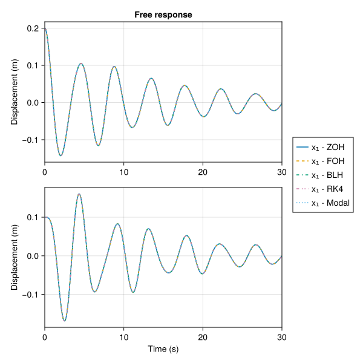

#### 1.2.2 Forced response

```julia
using LinearAlgebra

# Structural parameters
M = Diagonal([2., 1.])
K = [6. -2.; -2. 4.]
ξ = 0.05

ω, Φ = eigenmode(K, M)
C = modal_damping_matrix(M, ω, ξ, Φ)

# Time vector
t = 0.:1e-2:30.

# State-space model
css = ss_model(K, M, C)

F0 = 10.
tstart = 2.
duration = 5.
haversine = HaverSine(F0, tstart, duration)
F0 = excitation(haversine, t)
F = zeros(2, length(t))
F[1, :] .= F0

# Initial conditions
x0 = zeros(2)
v0 = zeros(2)
u0 = [x0; v0]

# Problem definition
prob_forced = StateSpaceTimeProblem(css, F, u0, t)
x_forced_zoh = solve(prob_forced).u
x_forced_foh = solve(prob_forced, :foh).u
x_forced_blh = solve(prob_forced, :blh).u
x_forced_rk = solve(prob_forced, :rk4).u

prob_forced_modal = ForcedModalTimeProblem(K, M, ξ, F, (x0, v0), t)
x_forced_modal = solve(prob_forced_modal).u
```

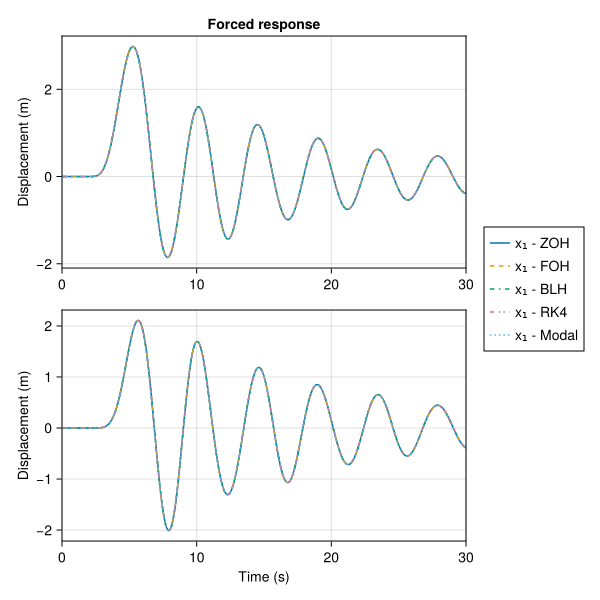

## 2 Frequency-domain solvers

The frequency-domain solvers are based on the state-space representation of the system, which includes both the state equation and the output equation. It is given that:
$$\begin{cases}
\dot{\mathbf{z}}(t) &= \mathbf{A}_c \mathbf{z}(t) + \mathbf{B}_c \mathbf{u}(t) \\
\mathbf{y}(t) &= \mathbf{C}_c \mathbf{z}(t) + \mathbf{D}_c \mathbf{u}(t)
\end{cases},$$
where:

- $\mathbf{z}(t)$: State vector
- $\mathbf{u}(t)$: Input vector
- $\mathbf{y}(t)$: Output vector
- $\mathbf{A}_c$: System matrix
- $\mathbf{B}_c$: Input matrix
- $\mathbf{C}_c$: Observation matrix
- $\mathbf{D}_c$: Direct feedthrough matrix

It is also possible to express the state-space system. To this end, the state-space representation is transformed into modal coordinates, i.e., $\mathbf{z} = \mathbf{\Psi} \mathbf{q}$, where $\mathbf{\Psi}$ is the matrix of eigenvectors of the system matrix $\mathbf{A}_c$. The modal state-space representation is given by:
$$\begin{cases}
\dot{\mathbf{q}}(t) &= \mathbf{\Lambda} \mathbf{q}(t) + \mathbf{B}_m \mathbf{u}(t) \\
\mathbf{y}(t) &= \mathbf{C}_m \mathbf{q}(t) + \mathbf{D}_m \mathbf{u}(t)
\end{cases},$$
where:

- $\mathbf{q}(t)$: Modal state vector
- $\Lambda = \text{diag}(\lambda_1, \lambda_1^\ast, \dots, \lambda_N, \lambda_N^\ast)$: Eigenvalues matrix
- $\mathbf{B}_m = \mathbf{\Psi}^{-1} \mathbf{B}_c$: Modal input matrix
- $\mathbf{C}_m = \mathbf{C}_c \mathbf{\Psi}$: Modal observation matrix
- $\mathbf{D}_m = \mathbf{D}_c$: Modal direct feedthrough matrix

### 2.1 Frequency Response Function

The Frequency Response Function (FRF) is a complex function that describes the steady-state response of a system to a sinusoidal input. The FRF is defined as the ratio of the output to the input in the frequency domain. From the state-space representation, the transfer function of the system at a given angular frequency $\omega$ can be obtained in a straightforward manner and is given by:
$$\mathbf{H}(\omega) = \mathbf{C}_c (j\omega \mathbf{I} - \mathbf{A}_c)^{-1} \mathbf{B}_c + \mathbf{D}_c,$$
or equivalently from the modes of the system:
$$\mathbf{H}(\omega) = \mathbf{C}_m (j\omega \mathbf{I} - \mathbf{\Lambda} )^{-1} \mathbf{B}_m + \mathbf{D}_m.$$

Finally, it should be noted that the FRF can be computed for a given set of response dofs and a given set of excitation dofs by introducing the appropriate selection matrices $\mathbf{S}_o$ and $\mathbf{S}_e$. In this case, the FRF is given by:
$$\mathbf{H}_{oe}(\omega) = \mathbf{S}_o\mathbf{H}(\omega)\mathbf{S}_e.$$

**Note**

- For the admittance : $\mathbf{C}_c = [\mathbf{I},\quad \mathbf{0}]$ and $\mathbf{D}_c = \mathbf{0}$.
- For the mobility : $\mathbf{C}_c = [\mathbf{0}, \quad \mathbf{I}]$ and $\mathbf{D}_c = \mathbf{0}$.
- For the accelerance, $\mathbf{C}_c = \mathbf{A}_c[m:\text{end}, :]$ and $\mathbf{D}_c = \mathbf{B}_c[m:\text{end}, :]$ with $m = N/2$ (this corresponds to a rewrite of the equation of motion).

#### 2.1.1 API

**Data types**

**StateSpaceFRFProblem**

```
StateSpaceFRFProblem(css::ContinuousStateSpace, freq, type, So, Se)
```

Structure containing the data feeding the direct solver for calculating an FRF

**Fields**

- `css`: Continuous-time state space model

- `freq`: Frequencies of interest

- `So`: Selection matrix for observation points

- `Se`: Selection matrix for excitation points

**Note** It is assumed that the output equation is of the form y = So*x

**StateSpaceModalFRFProblem**

```
StateSpacemodalFRFProblem(css::ContinuousStateSpace, freq, type, So, Se, n)
```

Structure containing the data feeding the direct solver for calculating an FRF

**Fields**

- `css`: Continuous-time state space model

- `freq`: Frequencies of interest

- `So`: Selection matrix for observation points

- `Se`: Selection matrix for excitation points

- `n`: Number of mode pairs to keep in the modal basis (default = size(css.Ac, 2) ÷ 2)

**Related function**

**solve**

```
solve(prob::StateSpaceFRFProblem; type = :dis, progress = true)
solve(prob::StateSpaceModalFRFProblem; type = :dis, progress = true)
```

Computes the FRF matrix by direct or modal method

**Inputs**

- `prob`: Structure containing the problem data

- `type`: Type of FRF to compute

  - `:dis`: Admittance

  - `:vel`: Mobility

  - `:acc`: Accelerance

- `progress`: Show progress bar (default = true)

**Output**

- `sol`: FRFSolution structure

  - `u`: FRF matrix

#### 2.1.2 Example

```julia
using LinearAlgebra

# Structural parameters
M = Diagonal([2., 1.])
K = [6. -2.; -2. 4.]
ξ = 0.05

ω, Φ = eigenmode(K, M)
C = modal_damping_matrix(M, ω, ξ, Φ)

# State-space model
css = ss_model(K, M, C)

# Frequency vector
freq = 0.01:0.001:1.

# Problem definition - Case 1 - Direct
prob_frf = StateSpaceFRFProblem(css, freq)
H_direct = solve(prob_frf).u

# Problem definition - Case 2 - Modal
prob_frf_modal = StateSpaceModalFRFProblem(css, freq)
H_modal = solve(prob_frf_modal).u
```

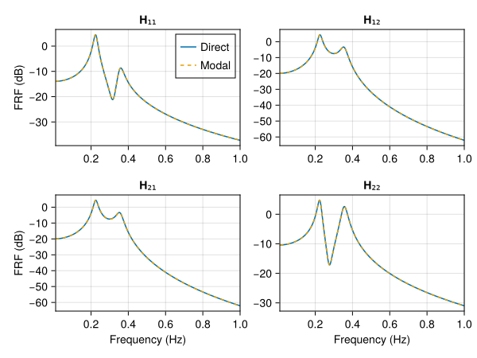

### 2.2 Response spectrum

Similarly to the FRF, the response spectrum is a complex function that describes the steady-state response of a system to a sinusoidal input. From the state-space representation, the response spectrum of the system at a given angular frequency $\omega$ is given by:
$$\mathbf{y}(\omega) = \left[\mathbf{C}_c (j\omega \mathbf{I} - \mathbf{A}_c)^{-1} \mathbf{B}_c + \mathbf{D}_c\right] \mathbf{u}(\omega),$$
or equivalently from the modes of the system:
$$\mathbf{y}(\omega) = \left[\mathbf{C}_m (j\omega \mathbf{I} - \mathbf{\Lambda} )^{-1} \mathbf{B}_m + \mathbf{D}_m\right] \mathbf{u}(\omega).$$

#### 2.2.1 API

**StateSpaceFreqProblem**

```
StateSpaceFreqProblem(css::ContinuousStateSpace, F, freq, So)
```

Structure containing the data feeding the modal solver for calculating the frequency response

**Fields**

- `css`: Continuous-time state space model

- `F`: External force matrix

- `freq`: Frequencies of interest

- `So`: Selection matrix for observation points

**StateSpaceModalFreqProblem**

```
StateSpaceModalFreqProblem(css::ContinuousStateSpace, F, freq, So, n)
```

Structure containing the data feeding the modal solver for calculating the frequency response

**Fields**

- `css`: Continuous-time state space model

- `F`: External force matrix

- `freq`: Frequencies of interest

- `So`: Selection matrix for observation points

- `n`: Number of mode pairs to keep in the modal basis (default = size(css.Ac, 2) ÷ 2)

**Related function**

**solve**

```
solve(prob::StateSpaceFreqProblem; type = :dis, progress = true)
solve(prob::StateSpaceFreqProblem; type = :dis, progress = true)
```

Computes the frequency response by direct or modal method

**Inputs**

- `prob`: Structure containing the problem data

- `type::Symbol`: Type of FRF to compute

  - `:dis`: Displacement

  - `:vel`: Velocity

  - `:acc`: Acceleration

- `progress`: Show progress bar

**Output** `sol`: Solution of the problem * `u`: Response spectrum matrix

#### 2.2.2 Example

```julia
using LinearAlgebra

# Structural parameters
M = Diagonal([2., 1.])
K = [6. -2.; -2. 4.]
ξ = 0.05

ω, Φ = eigenmode(K, M)
C = modal_damping_matrix(M, ω, ξ, Φ)

# State-space model
css = ss_model(K, M, C)

# Frequency vector
freq = 0.01:0.001:1.

# Force matrix
F = zeros(2, length(freq))
F[1, :] .= 10.

# Problem definition - Case 1 - Direct
prob_freq = StateSpaceFreqProblem(css, F, freq)
y_freq = solve(prob_freq).u

# Problem definition - Case 2 - Modal
prob_freq_modal = StateSpaceModalFreqProblem(css, F, freq)
y_freq_modal = solve(prob_freq_modal).u
```

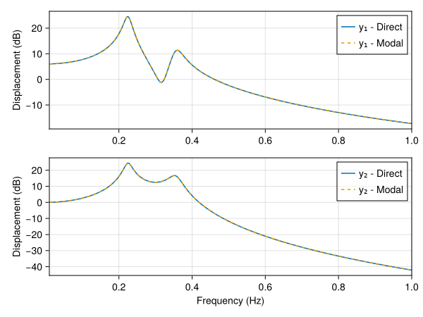